# Linear Regression using 30 Major League Base ball Teams ( Inspired by Money Ball)

10/30/2014

### Introduction:

The movie Moneyball focuses on the “quest for the secret of success in baseball”. It follows a low-budget team, the Oakland Athletics, who believed that underused statistics, such as a player’s ability to get on base, better predict the ability to score runs than typical statistics like home runs, RBIs (runs batted in), and batting average. Obtaining players who excelled in these underused statistics turned out to be much more affordable for the team.

In this exercise I will be looking at data from all 30 Major League Baseball teams and examining the linear relationship between runs scored in a season and a number of other player statistics. aim will be to summarize these relationships both graphically and numerically in order to find which variable, if any, helps best predict a team’s runs scored in a season.

### Data:

Data is collected for the 2011 season.

```r
names(mlb11)
```

```
##  [1] "team"         "runs"         "at_bats"      "hits"
##  [5] "homeruns"     "bat_avg"      "strikeouts"   "stolen_bases"
##  [9] "wins"         "new_onbase"   "new_slug"     "new_obs"
```

### Exploratory data analysis:

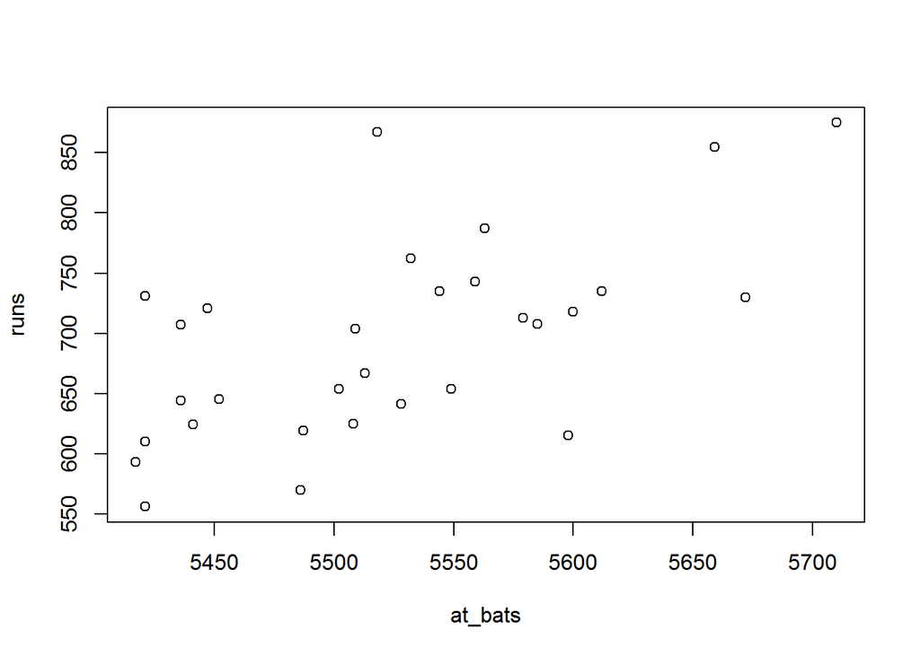

```r
attach(mlb11)
plot(at_bats,runs) ## we use scatterplot to observe correlation
```

```r
" Relation ship appears to be linear but not completely. we need to find correlation coefficient to determine how positively correlated.The relationship is positive, linear, and moderately strong. One of the potential outliers is a team with approximately 5520 at bats."
```

```
## [1] " Relation ship appears to be linear but not completely. we need to find correlation coefficient to determine how positively correlated.The relationship is positive, linear, and moderately strong. One of the potential outliers is a team with approximately 5520 at bats."
```

```r
##Correlation
 cor(runs,at_bats)
```

```
## [1] 0.6106
```

```r
##Summary of runs
summary(runs)
```

```
##    Min. 1st Qu.  Median    Mean 3rd Qu.    Max.
##     556     629     706     694     734     875
```

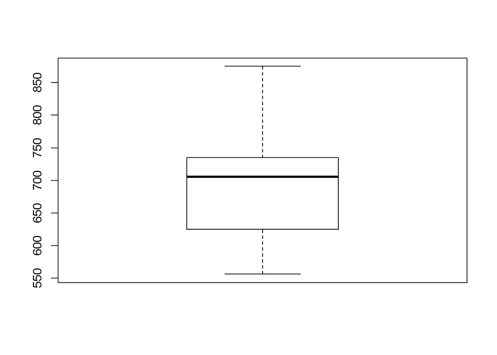

```r
boxplot(runs) #spread of runs
```

```r
##Summary of at_bats
summary(at_bats)
```

```
##    Min. 1st Qu.  Median    Mean 3rd Qu.    Max.
##    5420    5450    5520    5520    5580    5710
```

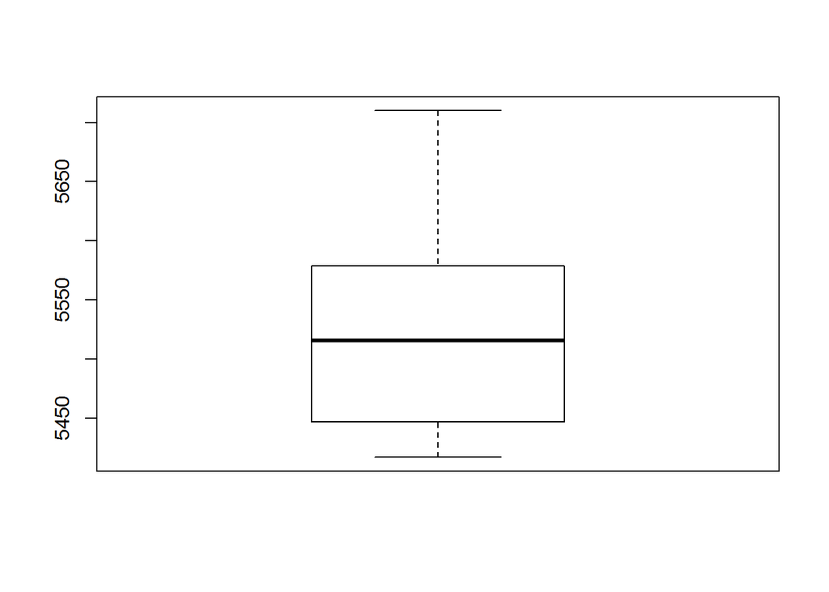

```r
boxplot(at_bats) #spread of at_bats
```

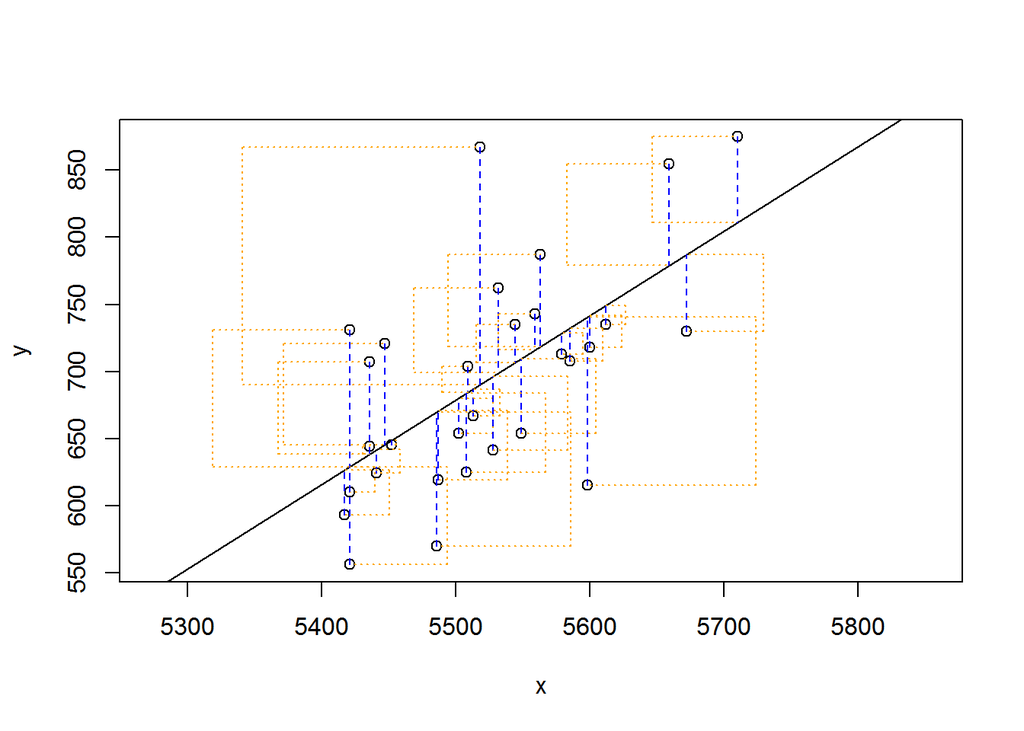

```
## Click two points to make a line.

## Call:
## lm(formula = y ~ x, data = pts)
##
## Coefficients:
## (Intercept)            x
##   -2789.243        0.631
##
## Sum of Squares:  123722
```

```r
##identifying lowest least sum of squares possible through plot_ss
plot_ss(x = at_bats, y = runs, showSquares = TRUE)
```

```r
## This is a very cumbersome process so we can use direct lm model
```

### Inference:

```r
## linear model in between at_bats and runs
m1 <- lm(runs ~ at_bats, data = mlb11)
summary(m1)
```

```
##
## Call:
## lm(formula = runs ~ at_bats, data = mlb11)
##
## Residuals:
##    Min     1Q Median     3Q    Max
## -125.6  -47.0  -16.6   54.4  176.9
##
## Coefficients:
##              Estimate Std. Error t value Pr(>|t|)
## (Intercept) -2789.243    853.696   -3.27  0.00287 **
## at_bats         0.631      0.155    4.08  0.00034 ***
## ---
## Signif. codes:  0 '***' 0.001 '**' 0.01 '*' 0.05 '.' 0.1 ' ' 1
##
## Residual standard error: 66.5 on 28 degrees of freedom
## Multiple R-squared:  0.373,  Adjusted R-squared:  0.35
## F-statistic: 16.6 on 1 and 28 DF,  p-value: 0.000339
```

" From this summary we can write least square regression line for linear model y = -2789.2429 + 0.6305 atbats

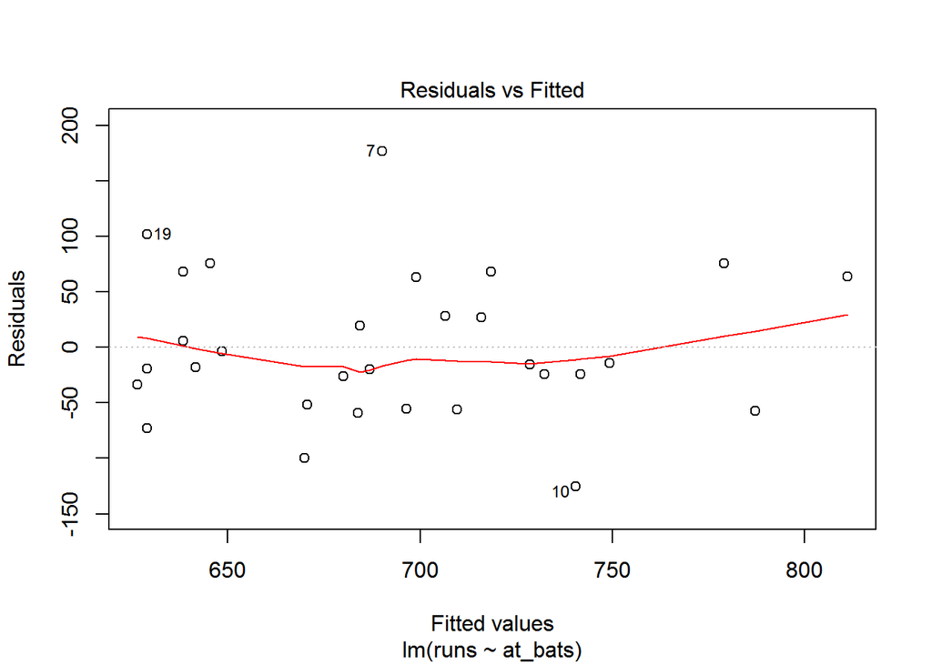

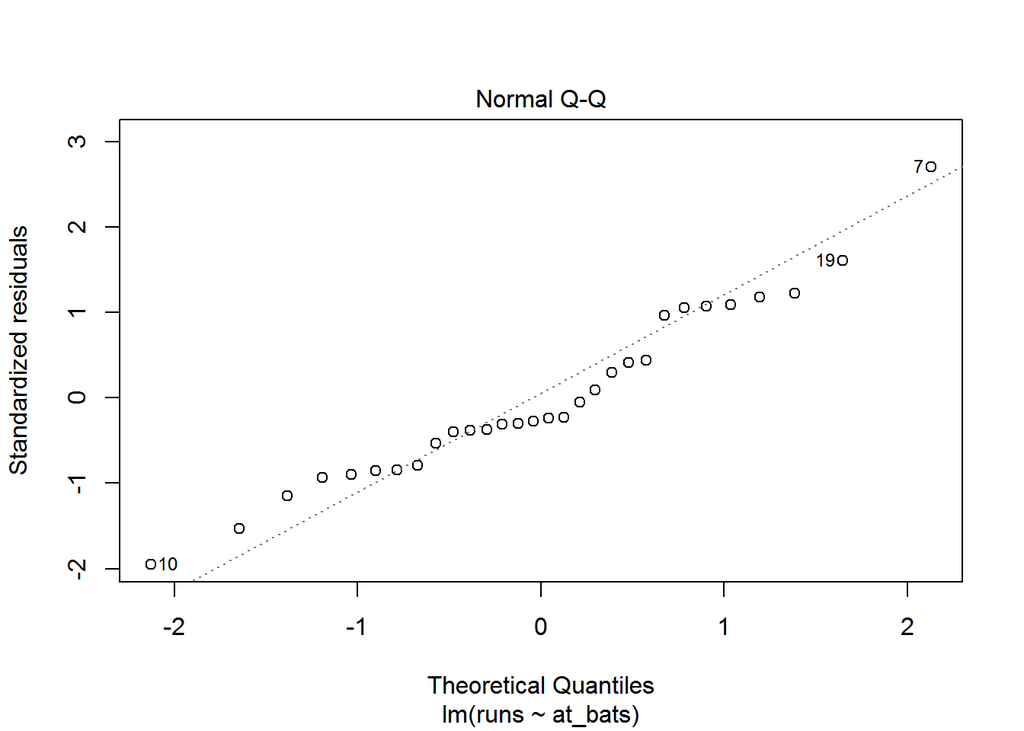

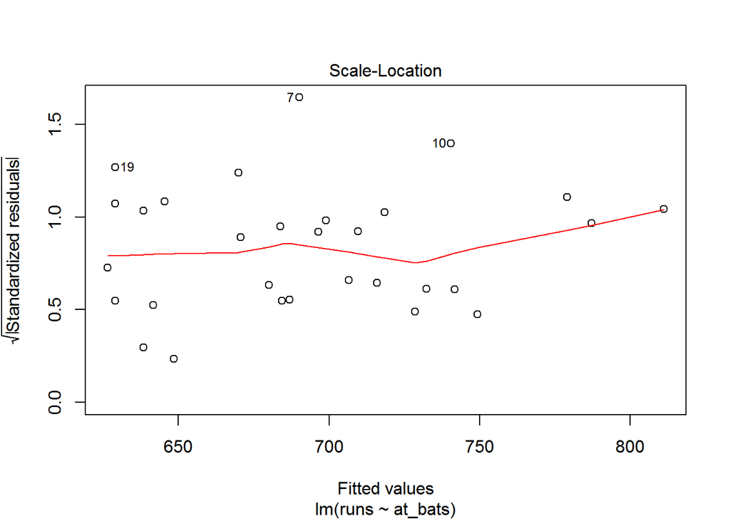

```r
plot(m1)
```

[figure not shown]

```r
abline(m1) # this function plots a line based on its slope and intercept
```

```r
"
When predictions are made for values of x that are beyond the range of the observed data, it is referred to as extrapolation. However, predictions made within the range of the data are more reliable. They're also used to compute the residuals.
"
```

```
## [1] "\nWhen predictions are made for values of x that are beyond the range of the observed data, it is referred to as extrapolation. However, predictions made within the range of the data are more reliable. They're also used to compute the residuals.\n"
```

```r
# caluculating residual at at_bats = 5579
 yobs <- mlb11[at_bats == "5579",2]
 y = -2789.2429 + 0.6305 * 5579
 e <- yobs - y
# from the result, this is overestimate or overprediciton by 15.31
#
```

## Model Diagnostics

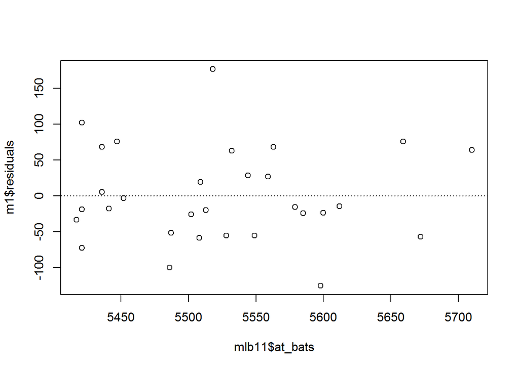

```r
#Random distribution of residuals Check
plot(m1$residuals ~ mlb11$at_bats)
abline(h = 0, lty = 3) # adds a horizontal dashed line at y = 0
```

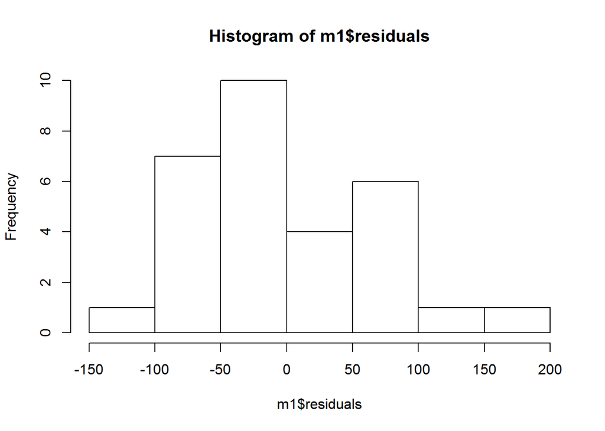

```r
# Normality Check ->
hist(m1$residuals)
```

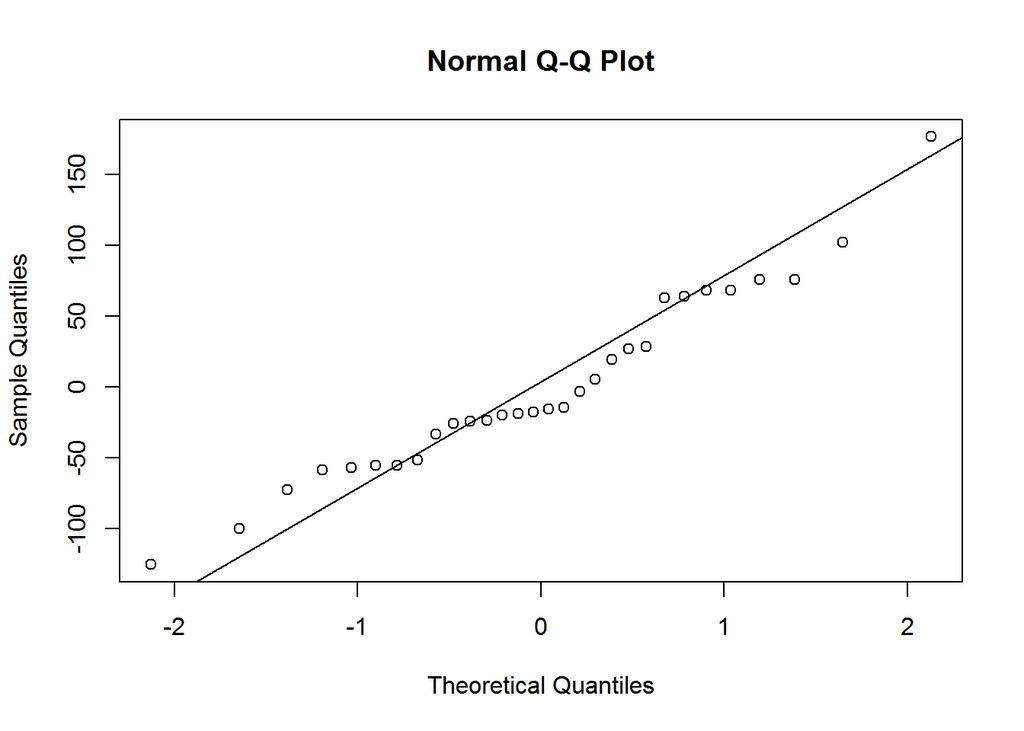

```r
qqnorm(m1$residuals)
qqline(m1$residuals) # adds diagonal line to the normal prob plot
```

```r
"
The residuals are failry symmetric, with only a slightly longer tail on the right, hence it would be appropriate to deem the the normal distribution of residuals condition met.
"
```

```
## [1] "\nThe residuals are failry symmetric, with only a slightly longer tail on the right, hence it would be appropriate to deem the the normal distribution of residuals condition met.\n"
```

```r
## constant variability
```

### Conclusion:

As Rsquared value is less. we can say the model is not good fit between runs and at_bats.

Lets verify the relation ships between runs and other possible variables. Relation between runs and homeruns

```r
hm<-lm(runs ~ homeruns)
summary(hm)
```

```
##
## Call:
## lm(formula = runs ~ homeruns)
##
## Residuals:
##    Min     1Q Median     3Q    Max
## -91.61 -33.41   3.23  24.29 104.63
##
## Coefficients:
##             Estimate Std. Error t value Pr(>|t|)
## (Intercept)  415.239     41.678    9.96  1.0e-10 ***
## homeruns       1.835      0.268    6.85  1.9e-07 ***
## ---
## Signif. codes:  0 '***' 0.001 '**' 0.01 '*' 0.05 '.' 0.1 ' ' 1
##
## Residual standard error: 51.3 on 28 degrees of freedom
## Multiple R-squared:  0.627,  Adjusted R-squared:  0.613
## F-statistic:   47 on 1 and 28 DF,  p-value: 1.9e-07
```

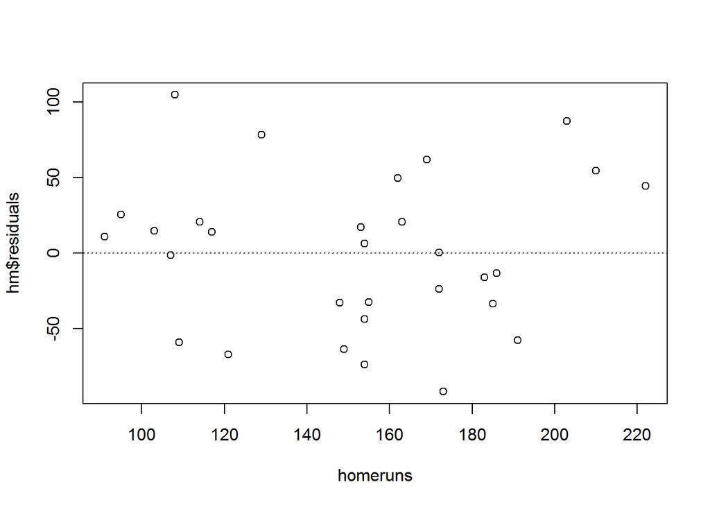

```r
#Random distribution of residuals Check
plot(hm$residuals ~ homeruns)
abline(h = 0, lty = 3) # adds a horizontal dashed line at y = 0
```

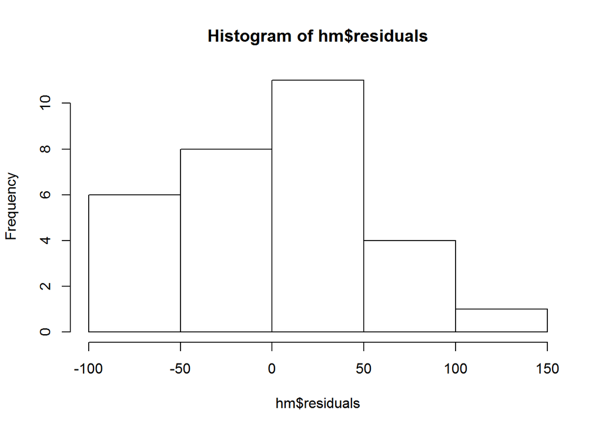

```r
# Normality Check ->
hist(hm$residuals)
```

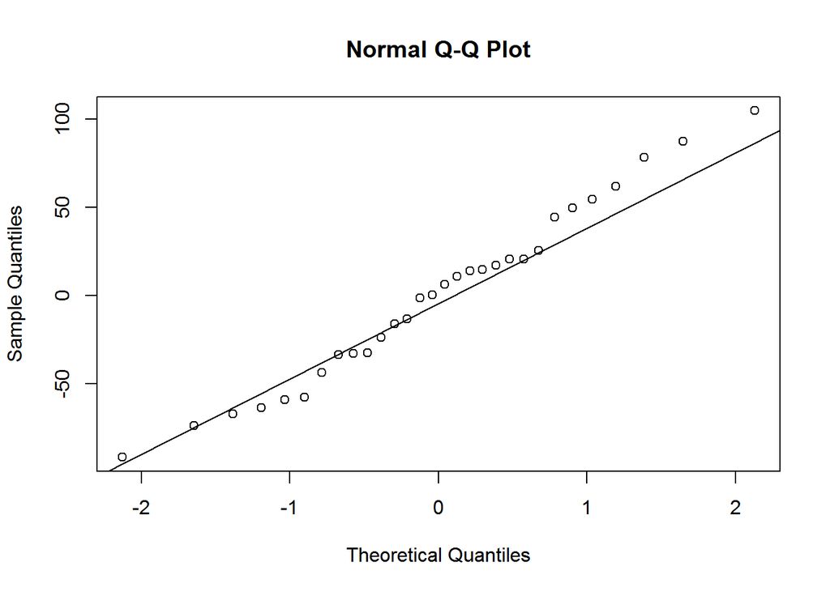

```r
qqnorm(hm$residuals)
qqline(hm$residuals) # adds diagonal line to the normal prob plot
```

```r
## constant variability
```

Relation between runs and batting average(bat_avg)

```r
ba<-lm(runs ~ bat_avg)
summary(ba)
```

```
##
## Call:
## lm(formula = runs ~ bat_avg)
##
## Residuals:
##    Min     1Q Median     3Q    Max
##  -94.7  -26.3   -5.5   28.5  131.1
##
## Coefficients:
##             Estimate Std. Error t value Pr(>|t|)
## (Intercept)     -643        183   -3.51   0.0015 **
## bat_avg         5242        717    7.31  5.9e-08 ***
## ---
## Signif. codes:  0 '***' 0.001 '**' 0.01 '*' 0.05 '.' 0.1 ' ' 1
##
## Residual standard error: 49.2 on 28 degrees of freedom
## Multiple R-squared:  0.656,  Adjusted R-squared:  0.644
## F-statistic: 53.4 on 1 and 28 DF,  p-value: 5.88e-08
```

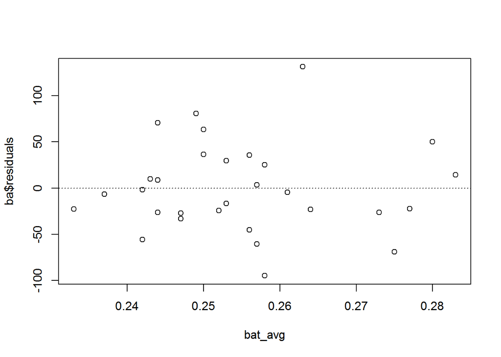

```r
#Random distribution of residuals Check
plot(ba$residuals ~ bat_avg)
abline(h = 0, lty = 3) # adds a horizontal dashed line at y = 0
```

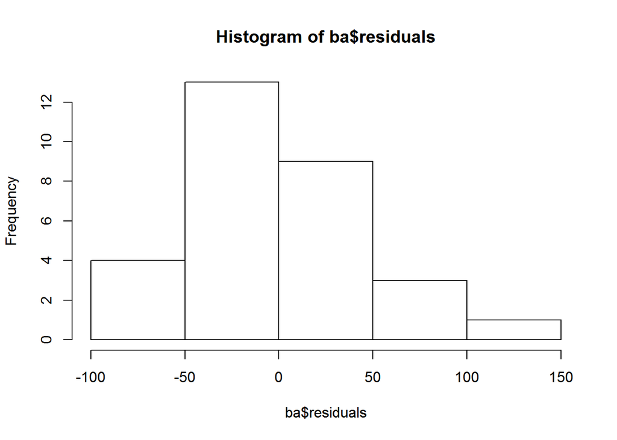

```r
# Normality Check ->
hist(ba$residuals)
```

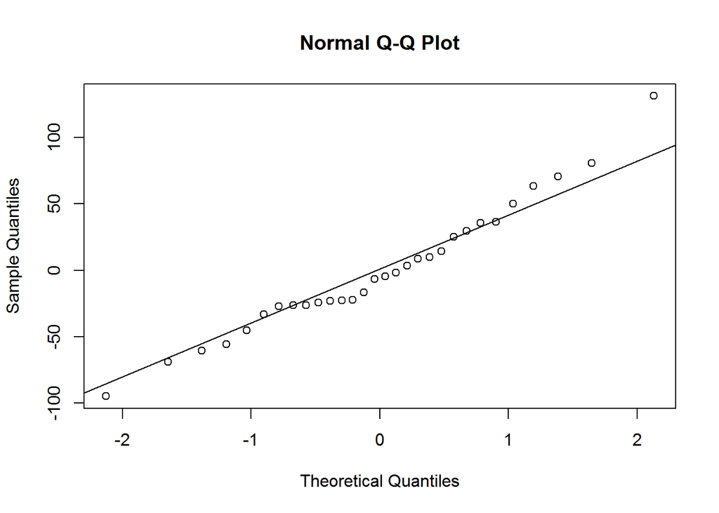

```r
qqnorm(ba$residuals)
qqline(ba$residuals) # adds diagonal line to the normal prob plot
```

```r
## constant variability
```

Relation between runs and wins

```r
wn<-lm(runs ~ wins)
summary(wn)
```

```
##
## Call:
## lm(formula = runs ~ wins)
##
## Residuals:
##     Min      1Q  Median      3Q     Max
## -145.45  -47.51   -7.48   47.35  142.19
##
## Coefficients:
##             Estimate Std. Error t value Pr(>|t|)
## (Intercept)   342.12      89.22    3.83  0.00065 ***
## wins            4.34       1.09    3.98  0.00045 ***
## ---
## Signif. codes:  0 '***' 0.001 '**' 0.01 '*' 0.05 '.' 0.1 ' ' 1
##
## Residual standard error: 67.1 on 28 degrees of freedom
## Multiple R-squared:  0.361,  Adjusted R-squared:  0.338
## F-statistic: 15.8 on 1 and 28 DF,  p-value: 0.000447
```

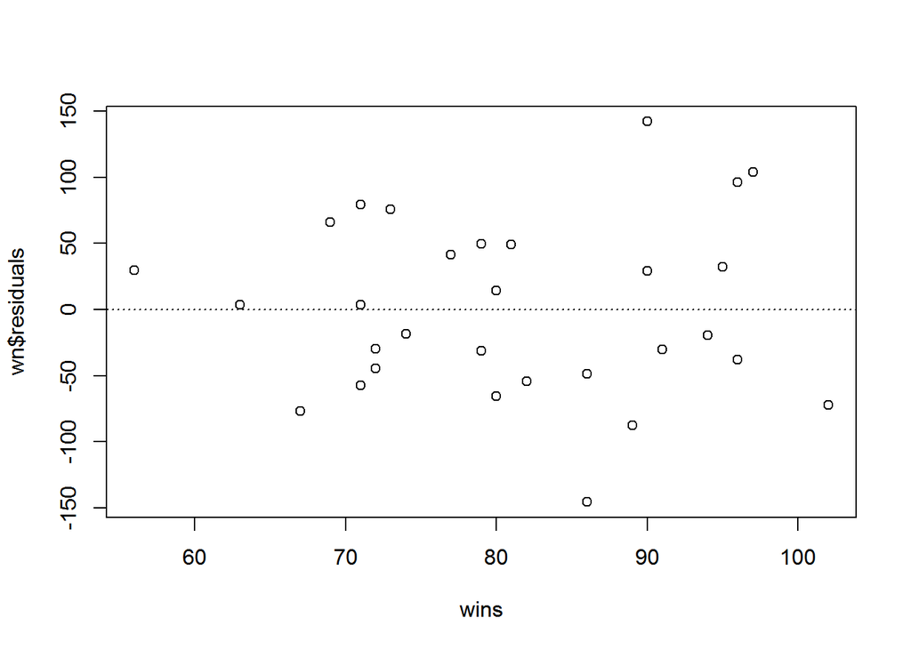

```r
#Random distribution of residuals Check
plot(wn$residuals ~ wins)
abline(h = 0, lty = 3) # adds a horizontal dashed line at y = 0
```

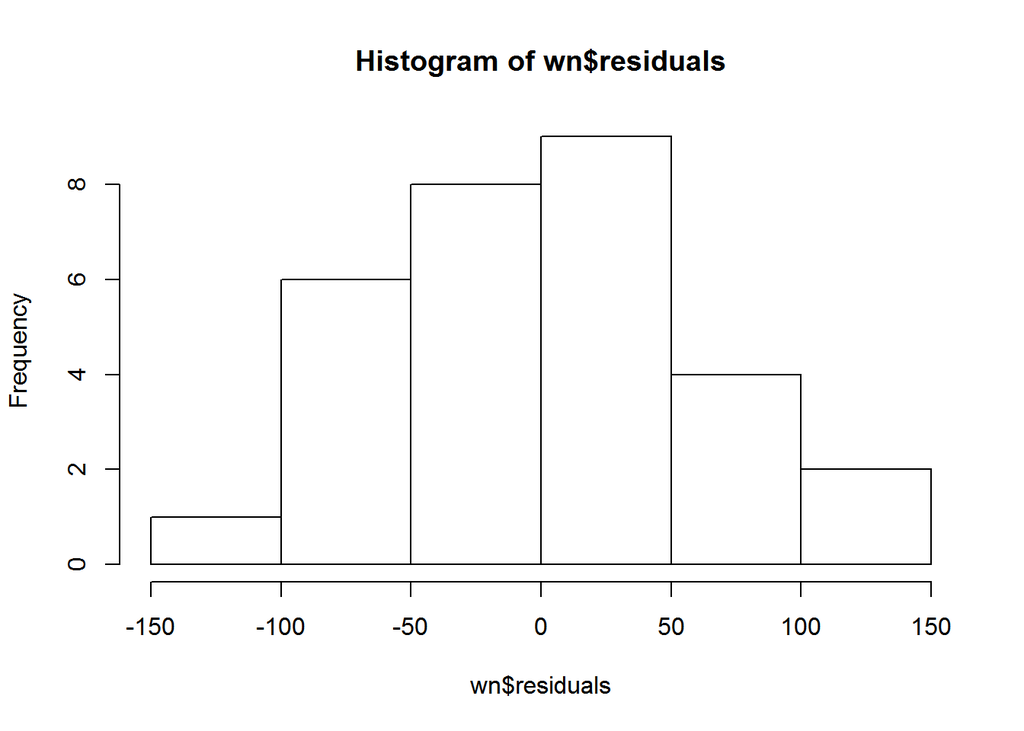

```r
# Normality Check ->
hist(wn$residuals)
```

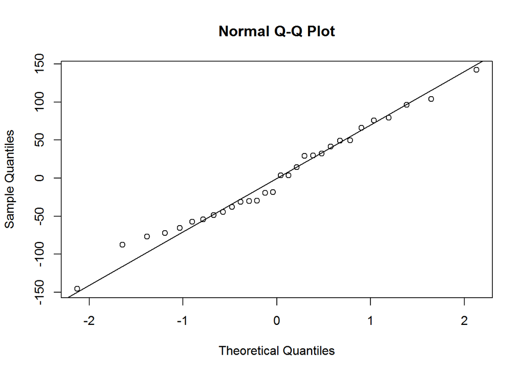

```r
qqnorm(wn$residuals)
qqline(wn$residuals) # adds diagonal line to the normal prob plot
```

```r
## constant variability
```

### Rsquared value for predition of runs with different explonatory variables

" at_bats : 0.373 home_runs : 0.627 batting average : 0.656 wins :0.361

The best fit could be possible with batting average . "